# Исследование закономерностей, определяющих успешность игр.

- Мы работаем в интернет-магазине «Стримчик», который продаёт по всему миру компьютерные игры. Из открытых источников доступны исторические данные о продажах игр, оценки пользователей и экспертов, жанры и платформы (например, Xbox или PlayStation). Нужно выявить определяющие успешность игры закономерности. Это позволит сделать ставку на потенциально популярный продукт и спланировать рекламные кампании.
- Перед нами данные до 2016 года. Представим, что сейчас декабрь 2016 г., и мы планируем кампанию на 2017-й.
- В наборе данных попадается аббревиатура ESRB (Entertainment Software Rating Board) — это ассоциация, определяющая возрастной рейтинг компьютерных игр. ESRB оценивает игровой контент и присваивает ему подходящую возрастную категорию, например, «Для взрослых», «Для детей младшего возраста» или «Для подростков».

Описание данных

- Name — название игры
- Platform — платформа
- Year_of_Release — год выпуска
- Genre — жанр игры
- NA_sales — продажи в Северной Америке (миллионы проданных копий)
- EU_sales — продажи в Европе (миллионы проданных копий)
- JP_sales — продажи в Японии (миллионы проданных копий)
- Other_sales — продажи в других странах (миллионы проданных копий)
- Critic_Score — оценка критиков (максимум 100)
- User_Score — оценка пользователей (максимум 10)
- Rating — рейтинг от организации ESRB (англ. Entertainment Software Rating Board). Эта ассоциация определяет рейтинг компьютерных игр и присваивает им подходящую возрастную категорию.

Данные за 2016 год могут быть неполными.

### Откроем файл с данными и изучим общую информацию

```python
import pandas as pd
import matplotlib.pyplot as plt
from scipy import stats as st
```

|  | Name | Platform | Year_of_Release | Genre | NA_sales | EU_sales | JP_sales | Other_sales | Critic_Score | User_Score | Rating |
| --- | --- | --- | --- | --- | --- | --- | --- | --- | --- | --- | --- |
| 0 | Wii Sports | Wii | 2006.0 | Sports | 41.36 | 28.96 | 3.77 | 8.45 | 76.0 | 8 | E |
| 1 | Super Mario Bros. | NES | 1985.0 | Platform | 29.08 | 3.58 | 6.81 | 0.77 | NaN | NaN | NaN |
| 2 | Mario Kart Wii | Wii | 2008.0 | Racing | 15.68 | 12.76 | 3.79 | 3.29 | 82.0 | 8.3 | E |
| 3 | Wii Sports Resort | Wii | 2009.0 | Sports | 15.61 | 10.93 | 3.28 | 2.95 | 80.0 | 8 | E |
| 4 | Pokemon Red/Pokemon Blue | GB | 1996.0 | Role-Playing | 11.27 | 8.89 | 10.22 | 1.00 | NaN | NaN | NaN |
| 5 | Tetris | GB | 1989.0 | Puzzle | 23.20 | 2.26 | 4.22 | 0.58 | NaN | NaN | NaN |
| 6 | New Super Mario Bros. | DS | 2006.0 | Platform | 11.28 | 9.14 | 6.50 | 2.88 | 89.0 | 8.5 | E |
| 7 | Wii Play | Wii | 2006.0 | Misc | 13.96 | 9.18 | 2.93 | 2.84 | 58.0 | 6.6 | E |
| 8 | New Super Mario Bros. Wii | Wii | 2009.0 | Platform | 14.44 | 6.94 | 4.70 | 2.24 | 87.0 | 8.4 | E |
| 9 | Duck Hunt | NES | 1984.0 | Shooter | 26.93 | 0.63 | 0.28 | 0.47 | NaN | NaN | NaN |

```
<class 'pandas.core.frame.DataFrame'>
RangeIndex: 16715 entries, 0 to 16714
Data columns (total 11 columns):
 #   Column           Non-Null Count  Dtype
---  ------           --------------  -----
 0   Name             16713 non-null  object
 1   Platform         16715 non-null  object
 2   Year_of_Release  16446 non-null  float64
 3   Genre            16713 non-null  object
 4   NA_sales         16715 non-null  float64
 5   EU_sales         16715 non-null  float64
 6   JP_sales         16715 non-null  float64
 7   Other_sales      16715 non-null  float64
 8   Critic_Score     8137 non-null   float64
 9   User_Score       10014 non-null  object
 10  Rating           9949 non-null   object
dtypes: float64(6), object(5)
memory usage: 1.4+ MB
```

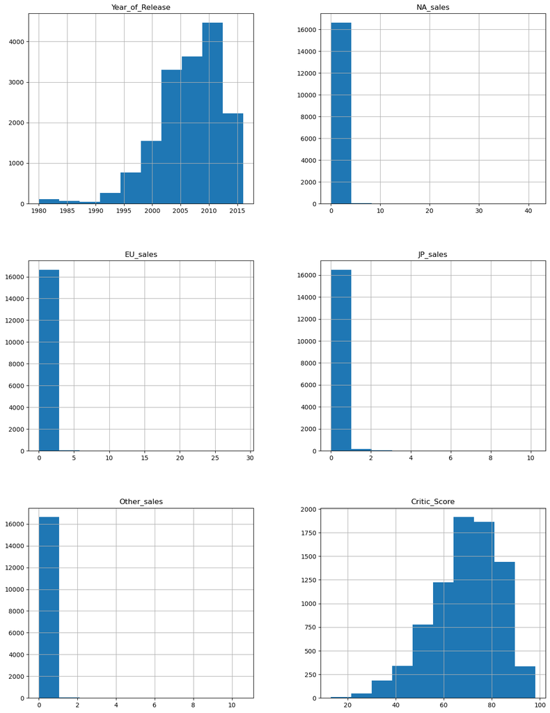

```python
data = pd.read_csv('../datasets/games.csv')
display(data.head(10))
data.info()
data.hist(figsize=(15,20));
```

### Предобработка данных

Приведем названия столбцов к нижнеме регистру:

```python
data.columns = data.columns.str.lower()
```

Преобразуем типы данных в столбцах:

```python
data['user_score'] = pd.to_numeric(data['user_score'], errors='coerce')
```

Заменил тип данных в столбце user_score на числовой, так как со строками невозможно выполнять арифметические действия. Параметр 'errors' принял как 'coerce', предположил что 'tbd' - предполагает отсутсвие пользовательского рейтинга, и заменил на 'NaN'.

Обработаем пропуски:

```python
data = data.dropna(subset=['name'])
data['rating'] = data['rating'].fillna('undefind')
data.info()
```

```
<class 'pandas.core.frame.DataFrame'>
Int64Index: 16713 entries, 0 to 16714
Data columns (total 11 columns):
 #   Column           Non-Null Count  Dtype
---  ------           --------------  -----
 0   name             16713 non-null  object
 1   platform         16713 non-null  object
 2   year_of_release  16444 non-null  float64
 3   genre            16713 non-null  object
 4   na_sales         16713 non-null  float64
 5   eu_sales         16713 non-null  float64
 6   jp_sales         16713 non-null  float64
 7   other_sales      16713 non-null  float64
 8   critic_score     8137 non-null   float64
 9   user_score       7590 non-null   float64
 10  rating           16713 non-null  object
dtypes: float64(7), object(4)
memory usage: 1.5+ MB
```

Удалил строки, с пропусками в названии и жанре, 2 строчки никак не повлияют на исследование, к тому же там также были пропущены и рейтинги. Пропуски в столбце 'rating' заменил на значение 'undefind'. Остальные пропуски оставил, так как количество пропусков слишком велико, на что-то заменить не представляется возможным. При их удалении, исследование будет сильно искажено.

Посчитайте суммарные продажи во всех регионах:

```python
data['total_sales'] = data[['na_sales','eu_sales','jp_sales', 'other_sales']].sum(axis = 1)
data.head()
```

|  | name | platform | year_of_release | genre | na_sales | eu_sales | jp_sales | other_sales | critic_score | user_score | rating | total_sales |
| --- | --- | --- | --- | --- | --- | --- | --- | --- | --- | --- | --- | --- |
| 0 | Wii Sports | Wii | 2006.0 | Sports | 41.36 | 28.96 | 3.77 | 8.45 | 76.0 | 8.0 | E | 82.54 |
| 1 | Super Mario Bros. | NES | 1985.0 | Platform | 29.08 | 3.58 | 6.81 | 0.77 | NaN | NaN | undefind | 40.24 |
| 2 | Mario Kart Wii | Wii | 2008.0 | Racing | 15.68 | 12.76 | 3.79 | 3.29 | 82.0 | 8.3 | E | 35.52 |
| 3 | Wii Sports Resort | Wii | 2009.0 | Sports | 15.61 | 10.93 | 3.28 | 2.95 | 80.0 | 8.0 | E | 32.77 |
| 4 | Pokemon Red/Pokemon Blue | GB | 1996.0 | Role-Playing | 11.27 | 8.89 | 10.22 | 1.00 | NaN | NaN | undefind | 31.38 |

Пропуски в названии и жанре игр, скорее всего вызваны программным сбоем при считывании данной информации. Пропуски в рейтинге критиков, пользовательском рейтинге и рейтинге ESRB, скорее всего, вызваны просто отсутствием рейтингов для данных игр.

### Исследовательский анализ

Посмотрим, сколько игр выпускалось в разные годы:

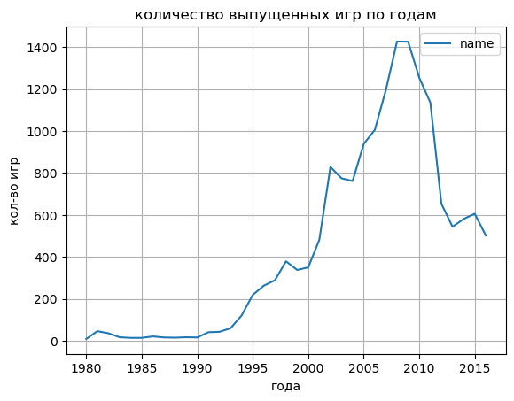

```python
years = data.pivot_table(index='year_of_release', values='name', aggfunc='count')
years.plot(title='количество выпущенных игр по годам', xlabel='года', ylabel='кол-во игр', grid=True);
```

Как видно из графика, кол-во выпускаемых стремительно росло до 2008 года, затем их количество начало снижаться. Ввиду небольшого выпуска игр до 2000 года, а также отсутствия рейтинга игр в эти года, считаю наиболее важными данными 2000-2016 года.

Выберем платформы, с наибольшими суммарными проадажами, и посмотрим за какой характерный срок появляются новые и исчезают старые платформы:

| platform | total_sales |
| --- | --- |
| PS2 | 1255.77 |
| X360 | 971.42 |
| PS3 | 939.65 |
| Wii | 907.51 |
| DS | 806.12 |
| PS | 730.86 |
| GBA | 317.85 |
| PS4 | 314.14 |
| PSP | 294.05 |
| PC | 259.52 |
| 3DS | 259.00 |
| XB | 257.74 |
| GB | 255.46 |
| NES | 251.05 |
| N64 | 218.68 |
| SNES | 200.04 |
| GC | 198.93 |
| XOne | 159.32 |
| 2600 | 96.98 |
| WiiU | 82.19 |
| PSV | 54.07 |
| SAT | 33.59 |
| GEN | 28.35 |
| DC | 15.95 |
| SCD | 1.86 |
| NG | 1.44 |
| WS | 1.42 |
| TG16 | 0.16 |
| 3DO | 0.10 |
| GG | 0.04 |
| PCFX | 0.03 |

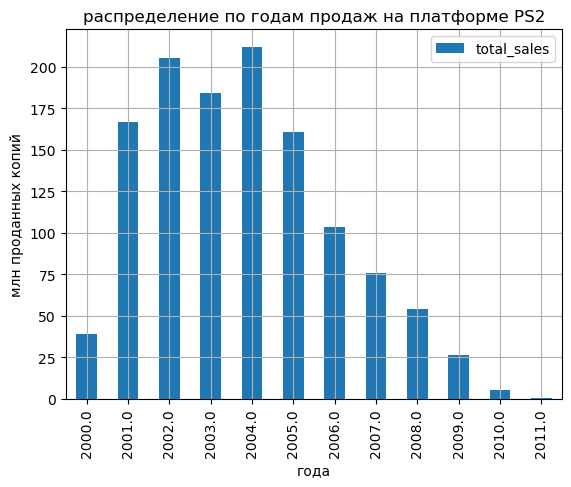

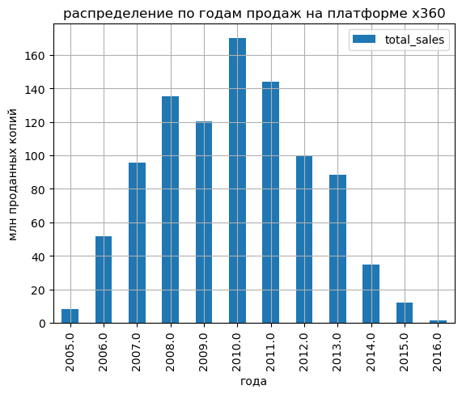

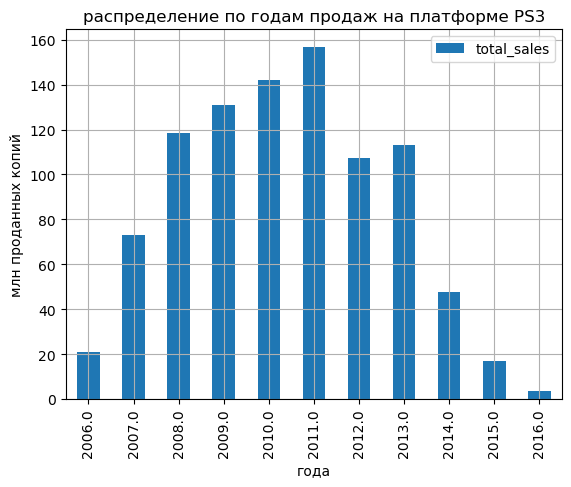

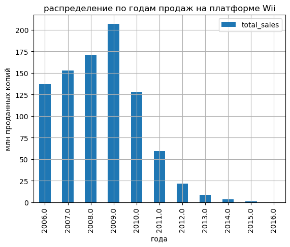

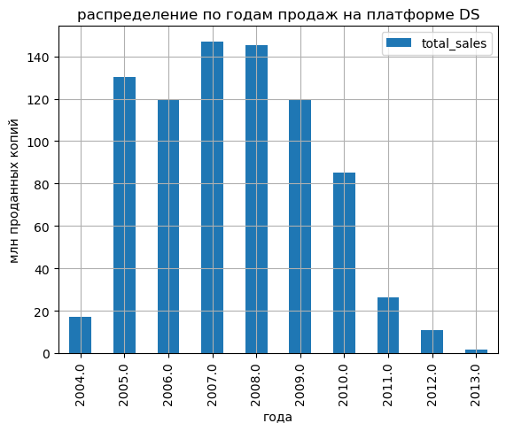

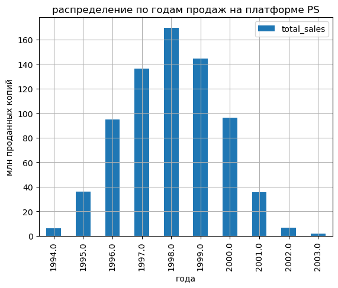

```python
platform = data.pivot_table(index='platform', values='total_sales', aggfunc='sum').sort_values(by='total_sales', ascending=False)
display(platform)
data[data['platform'] == 'PS2'].pivot_table(index='year_of_release', values='total_sales', aggfunc='sum') \
.plot(title='распределение по годам продаж на платформе PS2', xlabel='года', ylabel='млн проданных копий', grid=True, kind='bar')
data[data['platform'] == 'X360'].pivot_table(index='year_of_release', values='total_sales', aggfunc='sum') \
.plot(title='распределение по годам продаж на платформе x360', xlabel='года', ylabel='млн проданных копий', grid=True, kind='bar')
data[data['platform'] == 'PS3'].pivot_table(index='year_of_release', values='total_sales', aggfunc='sum') \
.plot(title='распределение по годам продаж на платформе PS3', xlabel='года', ylabel='млн проданных копий', grid=True, kind='bar')
data[data['platform'] == 'Wii'].pivot_table(index='year_of_release', values='total_sales', aggfunc='sum') \
.plot(title='распределение по годам продаж на платформе Wii', xlabel='года', ylabel='млн проданных копий', grid=True, kind='bar')
data[(data['platform'] == 'DS') & (data['year_of_release'] >=2004)].pivot_table(index='year_of_release', values='total_sales', aggfunc='sum') \
.plot(title='распределение по годам продаж на платформе DS', xlabel='года', ylabel='млн проданных копий', grid=True, kind='bar')
data[data['platform'] == 'PS'].pivot_table(index='year_of_release', values='total_sales', aggfunc='sum') \
.plot(title='распределение по годам продаж на платформе PS', xlabel='года', ylabel='млн проданных копий', grid=True, kind='bar');
```

Из графиков видно, что период "жизни" каждой из платформ 9-10 лет. Для построения прогноза на 2017, возмём данные с 2014 года по 2016, так как игровая индуствия бурно развивающася и быстро изменяющаяся. На этом периоде мы сможем определить, какие плафтормы сейчас пользуются спросом, и самое главное, какие будут пользоваться спросом в 2017 году.

Выберем потенциально прибыльные платформы:

| platform | total_sales |
| --- | --- |
| PS4 | 288.15 |
| XOne | 140.36 |
| 3DS | 86.68 |
| PS3 | 68.18 |
| X360 | 48.22 |
| WiiU | 42.98 |
| PC | 27.05 |
| PSV | 22.40 |
| Wii | 5.07 |
| PSP | 0.36 |

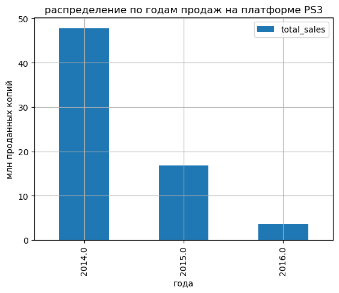

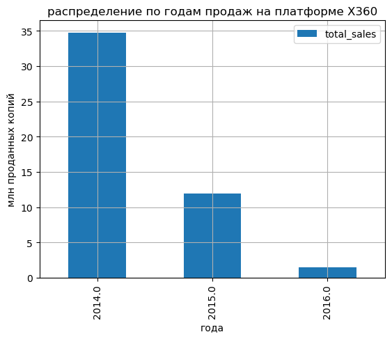

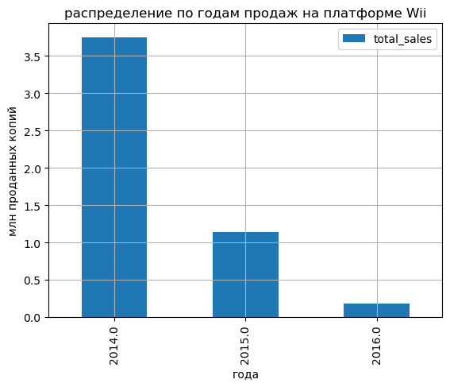

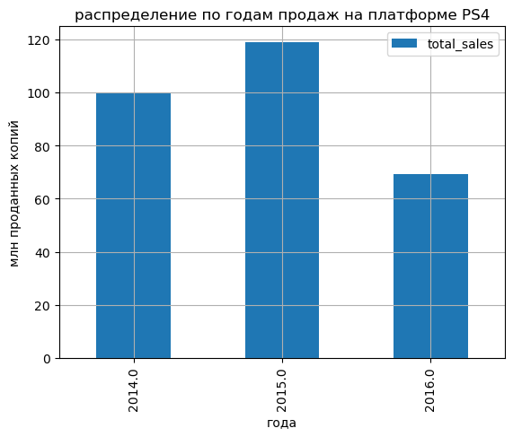

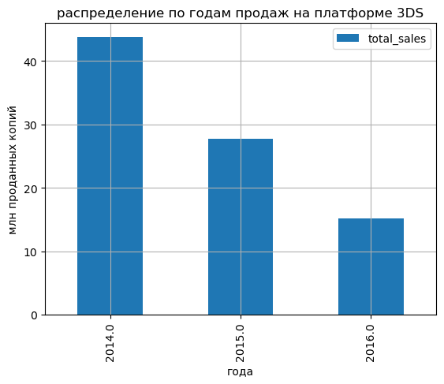

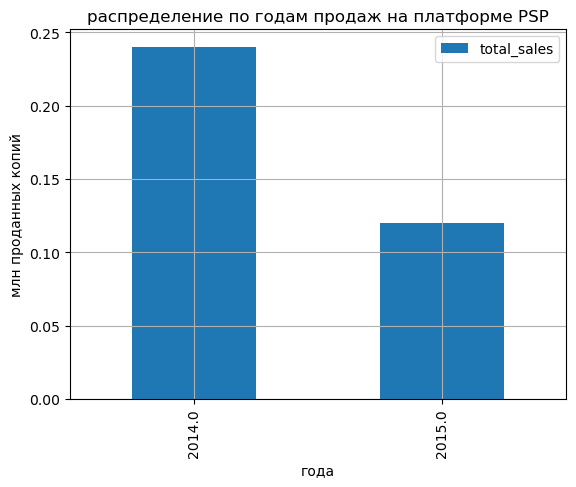

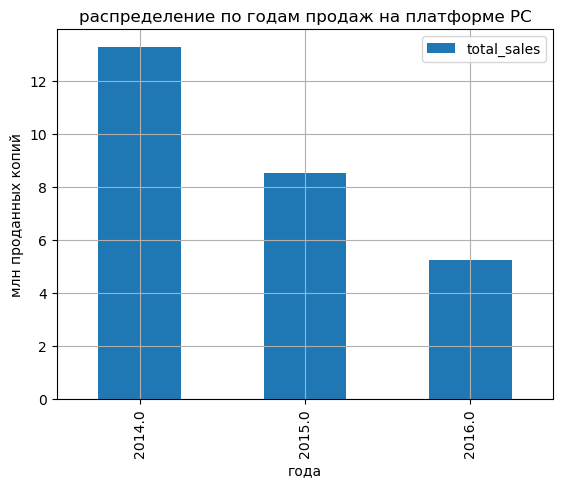

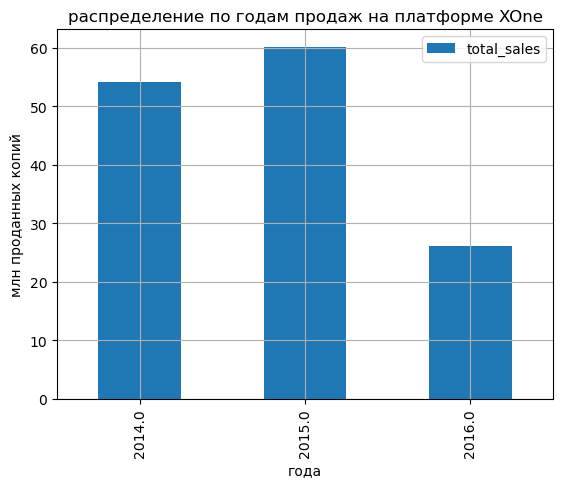

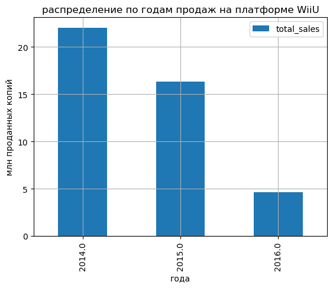

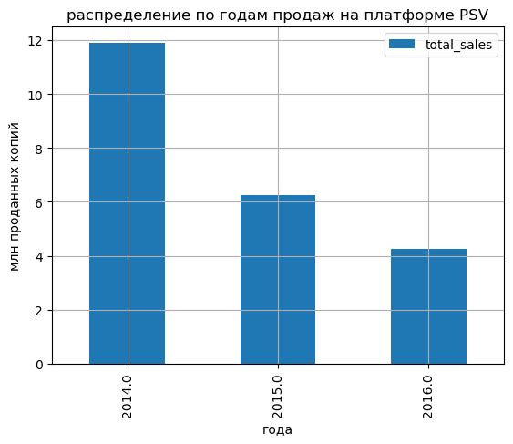

```python
data2 = data[data['year_of_release'] >= 2014].reset_index()
platform2 = data2.pivot_table(index='platform', values='total_sales', aggfunc='sum').sort_values(by='total_sales', ascending=False)
display(platform2)
data2[data2['platform'] == 'PS3'].pivot_table(index='year_of_release', values='total_sales', aggfunc='sum') \
.plot(title='распределение по годам продаж на платформе PS3', xlabel='года', ylabel='млн проданных копий', grid=True, kind='bar')
data2[data2['platform'] == 'X360'].pivot_table(index='year_of_release', values='total_sales', aggfunc='sum') \
.plot(title='распределение по годам продаж на платформе X360', xlabel='года', ylabel='млн проданных копий', grid=True, kind='bar')
data2[data2['platform'] == 'Wii'].pivot_table(index='year_of_release', values='total_sales', aggfunc='sum') \
.plot(title='распределение по годам продаж на платформе Wii', xlabel='года', ylabel='млн проданных копий', grid=True, kind='bar')
data2[data2['platform'] == 'PS4'].pivot_table(index='year_of_release', values='total_sales', aggfunc='sum') \
.plot(title='распределение по годам продаж на платформе PS4', xlabel='года', ylabel='млн проданных копий', grid=True, kind='bar')
data2[data2['platform'] == '3DS'].pivot_table(index='year_of_release', values='total_sales', aggfunc='sum') \
.plot(title='распределение по годам продаж на платформе 3DS', xlabel='года', ylabel='млн проданных копий', grid=True, kind='bar')
data2[data2['platform'] == 'PSP'].pivot_table(index='year_of_release', values='total_sales', aggfunc='sum') \
.plot(title='распределение по годам продаж на платформе PSP', xlabel='года', ylabel='млн проданных копий', grid=True, kind='bar')
data2[data2['platform'] == 'PC'].pivot_table(index='year_of_release', values='total_sales', aggfunc='sum') \
.plot(title='распределение по годам продаж на платформе PC', xlabel='года', ylabel='млн проданных копий', grid=True, kind='bar')
data2[data2['platform'] == 'XOne'].pivot_table(index='year_of_release', values='total_sales', aggfunc='sum') \
.plot(title='распределение по годам продаж на платформе XOne', xlabel='года', ylabel='млн проданных копий', grid=True, kind='bar')
data2[data2['platform'] == 'WiiU'].pivot_table(index='year_of_release', values='total_sales', aggfunc='sum') \
.plot(title='распределение по годам продаж на платформе WiiU', xlabel='года', ylabel='млн проданных копий', grid=True, kind='bar')
data2[data2['platform'] == 'PSV'].pivot_table(index='year_of_release', values='total_sales', aggfunc='sum') \
.plot(title='распределение по годам продаж на платформе PSV', xlabel='года', ylabel='млн проданных копий', grid=True, kind='bar');
```

Из графиков видно, что лидером по продажам игры в последние года является PS4. Также высокие продажи имеют платформы XOne и 3DS, их мы и выберем, как потенциально прибыльные платформы. Но по всем платформам идет спад продаж.

Построим график "ящик с усами" по глобальным продажам игр, в разбивке по платформам:

|  | index | year_of_release | na_sales | eu_sales | jp_sales | other_sales | critic_score | user_score | total_sales |
| --- | --- | --- | --- | --- | --- | --- | --- | --- | --- |
| count | 376.000000 | 376.000000 | 376.000000 | 376.000000 | 376.000000 | 376.000000 | 237.000000 | 242.000000 | 376.000000 |
| mean | 8045.797872 | 2015.236702 | 0.262261 | 0.345851 | 0.039947 | 0.118298 | 72.164557 | 6.828099 | 0.766356 |
| std | 5274.742697 | 0.762336 | 0.583439 | 0.815480 | 0.067048 | 0.256506 | 12.214985 | 1.399035 | 1.614969 |
| min | 31.000000 | 2014.000000 | 0.000000 | 0.000000 | 0.000000 | 0.000000 | 19.000000 | 1.500000 | 0.010000 |
| 25% | 2969.000000 | 2015.000000 | 0.000000 | 0.000000 | 0.000000 | 0.000000 | 66.000000 | 6.200000 | 0.057500 |
| 50% | 8015.000000 | 2015.000000 | 0.050000 | 0.070000 | 0.015000 | 0.020000 | 73.000000 | 7.100000 | 0.185000 |
| 75% | 12918.500000 | 2016.000000 | 0.240000 | 0.280000 | 0.050000 | 0.102500 | 80.000000 | 7.875000 | 0.690000 |
| max | 16585.000000 | 2016.000000 | 6.030000 | 6.310000 | 0.490000 | 2.380000 | 97.000000 | 9.200000 | 14.630000 |

|  | index | year_of_release | na_sales | eu_sales | jp_sales | other_sales | critic_score | user_score | total_sales |
| --- | --- | --- | --- | --- | --- | --- | --- | --- | --- |
| count | 228.000000 | 228.000000 | 228.000000 | 228.000000 | 228.000000 | 228.000000 | 155.000000 | 165.000000 | 228.000000 |
| mean | 8052.574561 | 2015.114035 | 0.356447 | 0.202851 | 0.001404 | 0.054912 | 73.793548 | 6.594545 | 0.615614 |
| std | 5378.551245 | 0.799325 | 0.634756 | 0.371972 | 0.005289 | 0.095065 | 12.252589 | 1.375139 | 1.046513 |
| min | 99.000000 | 2014.000000 | 0.000000 | 0.000000 | 0.000000 | 0.000000 | 20.000000 | 1.600000 | 0.010000 |
| 25% | 3166.250000 | 2014.000000 | 0.030000 | 0.020000 | 0.000000 | 0.000000 | 66.500000 | 5.800000 | 0.050000 |
| 50% | 7607.500000 | 2015.000000 | 0.100000 | 0.070000 | 0.000000 | 0.020000 | 76.000000 | 6.800000 | 0.205000 |
| 75% | 13013.500000 | 2016.000000 | 0.352500 | 0.210000 | 0.000000 | 0.052500 | 83.000000 | 7.600000 | 0.632500 |
| max | 16672.000000 | 2016.000000 | 4.590000 | 2.190000 | 0.040000 | 0.680000 | 97.000000 | 9.200000 | 7.390000 |

|  | index | year_of_release | na_sales | eu_sales | jp_sales | other_sales | critic_score | user_score | total_sales |
| --- | --- | --- | --- | --- | --- | --- | --- | --- | --- |
| count | 212.000000 | 212.000000 | 212.000000 | 212.000000 | 212.000000 | 212.000000 | 51.000000 | 55.000000 | 212.000000 |
| mean | 10048.683962 | 2014.839623 | 0.106792 | 0.076038 | 0.208679 | 0.017358 | 68.980392 | 7.138182 | 0.408868 |
| std | 4732.647094 | 0.755853 | 0.440719 | 0.295478 | 0.529456 | 0.070365 | 12.858445 | 1.503513 | 1.188368 |
| min | 47.000000 | 2014.000000 | 0.000000 | 0.000000 | 0.000000 | 0.000000 | 26.000000 | 2.400000 | 0.010000 |
| 25% | 6628.500000 | 2014.000000 | 0.000000 | 0.000000 | 0.010000 | 0.000000 | 63.500000 | 6.500000 | 0.030000 |
| 50% | 11259.500000 | 2015.000000 | 0.000000 | 0.000000 | 0.055000 | 0.000000 | 69.000000 | 7.400000 | 0.090000 |
| 75% | 14058.000000 | 2015.000000 | 0.050000 | 0.040000 | 0.132500 | 0.010000 | 78.500000 | 8.200000 | 0.250000 |
| max | 16677.000000 | 2016.000000 | 4.350000 | 3.490000 | 3.180000 | 0.740000 | 90.000000 | 9.000000 | 11.680000 |

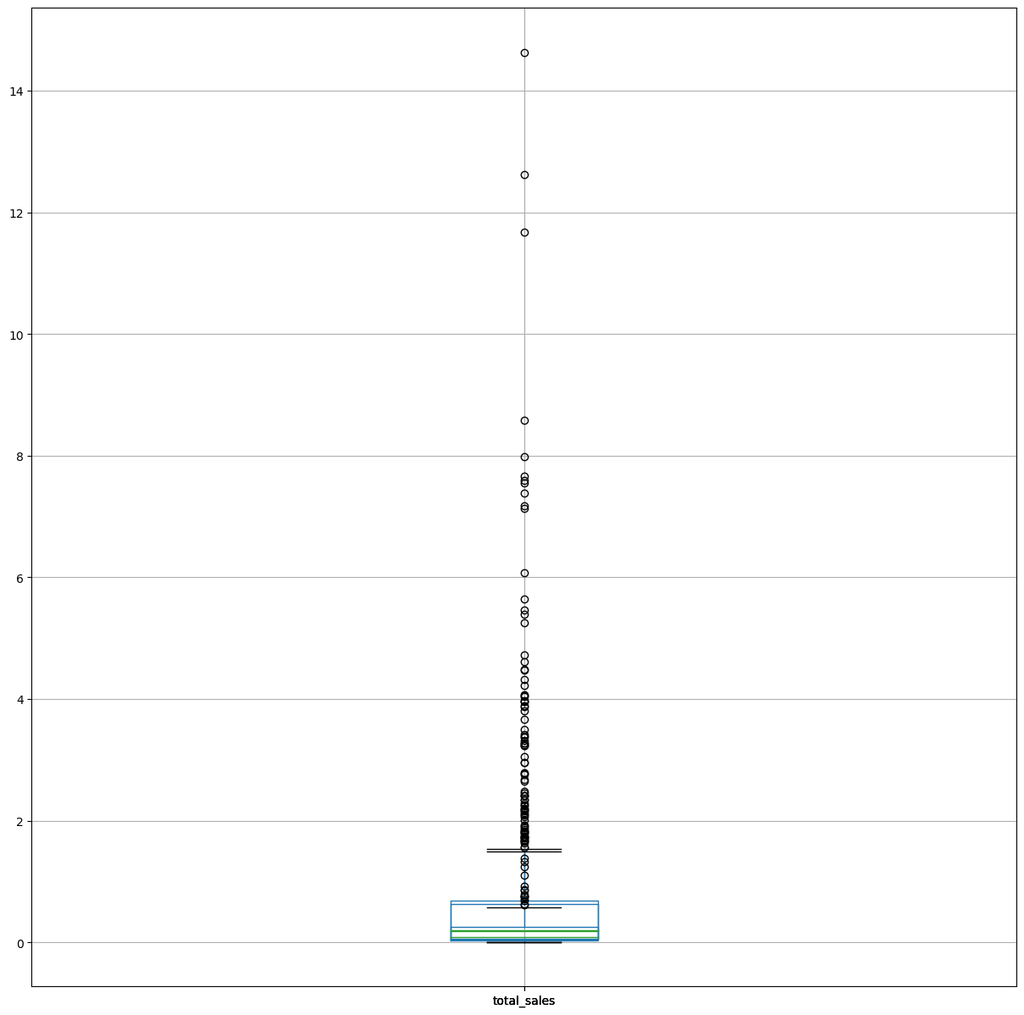

```python
data2[data2['platform'] == 'PS4'].boxplot(column='total_sales', figsize=(15,15))
display(data2[data2['platform'] == 'PS4'].describe())
data2[data2['platform'] == 'XOne'].boxplot(column='total_sales', figsize=(15,15))
display(data2[data2['platform'] == 'XOne'].describe())
data2[data2['platform'] == '3DS'].boxplot(column='total_sales', figsize=(15,15));
display(data2[data2['platform'] == '3DS'].describe())
```

Посмотрим, как влияют на продажи внутри одной популярной платформы отзывы пользователей и критиков:

```
'коэффициент корреляции общих продаж от оценки  критиков для PS4:'
```

```
0.40266141068104083
```

```
'коэффициент корреляции общих продаж от оценки  пользователей для PS4:'
```

```
-0.040131589472697356
```

```
'коэффициент корреляции общих продаж от оценки  критиков для XOne:'
```

```
0.42867694370333226
```

```
'коэффициент корреляции общих продаж от оценки  пользователей для XOne:'
```

```
-0.0703839280647581
```

```
'коэффициент корреляции общих продаж от оценки  критиков для 3DS:'
```

```
0.31411749286905105
```

```
'коэффициент корреляции общих продаж от оценки  пользователей для 3DS:'
```

```
0.2151932718527028
```

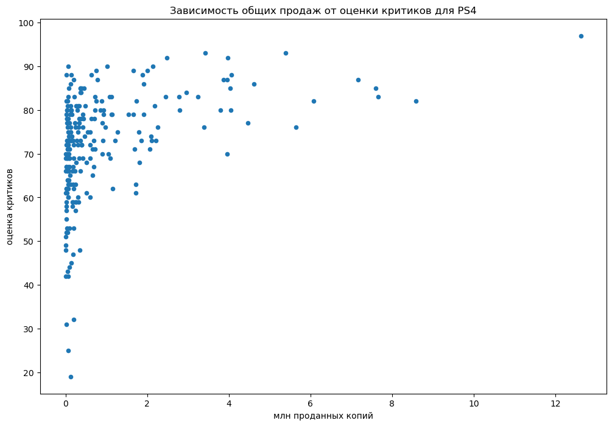

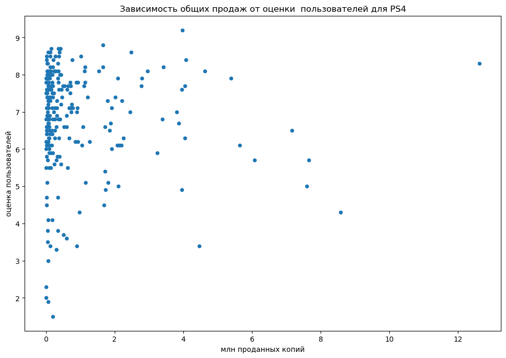

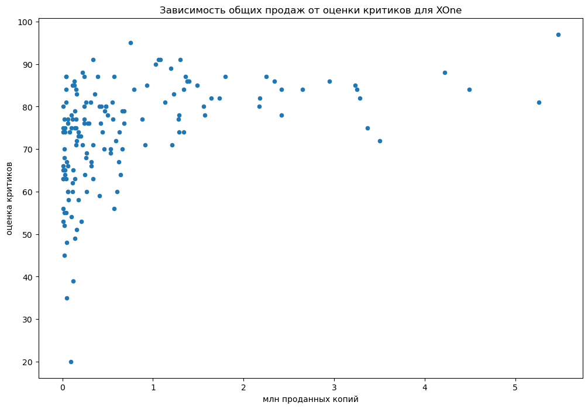

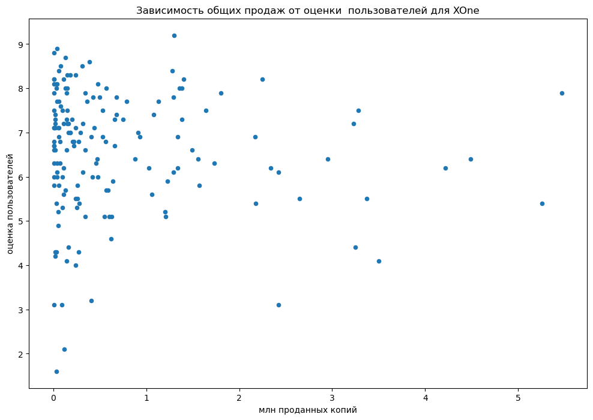

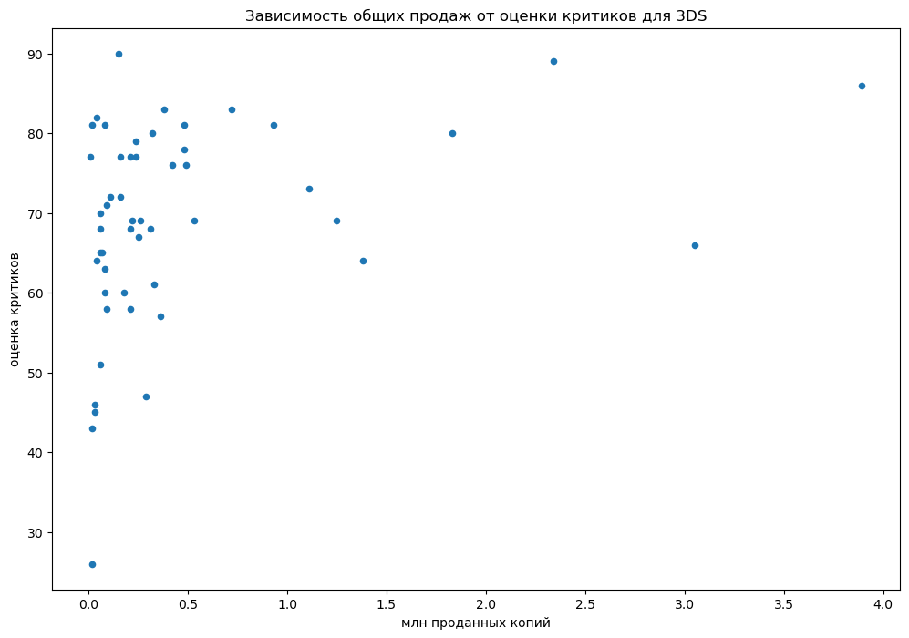

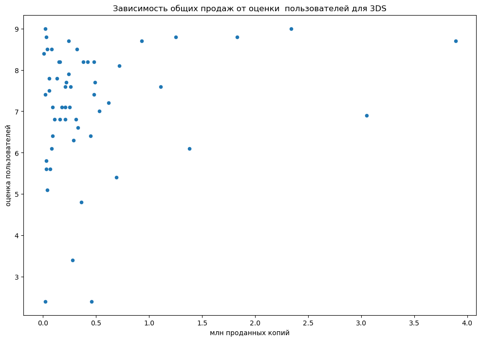

```python
data2[data2['platform'] == 'PS4'].plot(x='total_sales', y='critic_score', kind='scatter', figsize=(12,8), \
                                       title='Зависимость общих продаж от оценки критиков для PS4', \
                                      xlabel='млн проданных копий', ylabel='оценка критиков')
data2[data2['platform'] == 'PS4'].plot(x='total_sales', y='user_score', kind='scatter', figsize=(12,8), \
                                       title='Зависимость общих продаж от оценки  пользователей для PS4', \
                                      xlabel='млн проданных копий', ylabel='оценка пользователей')
display('коэффициент корреляции общих продаж от оценки  критиков для PS4:', \
        data2.loc[data2['platform'] == 'PS4','total_sales'].corr(data2.loc[data2['platform'] == 'PS4','critic_score']))
display('коэффициент корреляции общих продаж от оценки  пользователей для PS4:', \
        data2.loc[data2['platform'] == 'PS4','total_sales'].corr(data2.loc[data2['platform'] == 'PS4','user_score']))
data2[data2['platform'] == 'XOne'].plot(x='total_sales', y='critic_score', kind='scatter', figsize=(12,8), \
                                       title='Зависимость общих продаж от оценки критиков для XOne', \
                                      xlabel='млн проданных копий', ylabel='оценка критиков')
data2[data2['platform'] == 'XOne'].plot(x='total_sales', y='user_score', kind='scatter', figsize=(12,8), \
                                       title='Зависимость общих продаж от оценки  пользователей для XOne', \
                                      xlabel='млн проданных копий', ylabel='оценка пользователей')
display('коэффициент корреляции общих продаж от оценки  критиков для XOne:', \
        data2.loc[data2['platform'] == 'XOne','total_sales'].corr(data2.loc[data2['platform'] == 'XOne','critic_score']))
display('коэффициент корреляции общих продаж от оценки  пользователей для XOne:', \
        data2.loc[data2['platform'] == 'XOne','total_sales'].corr(data2.loc[data2['platform'] == 'XOne','user_score']))
data2[data2['platform'] == '3DS'].plot(x='total_sales', y='critic_score', kind='scatter', figsize=(12,8), \
                                       title='Зависимость общих продаж от оценки критиков для 3DS', \
                                      xlabel='млн проданных копий', ylabel='оценка критиков')
data2[data2['platform'] == '3DS'].plot(x='total_sales', y='user_score', kind='scatter', figsize=(12,8), \
                                       title='Зависимость общих продаж от оценки  пользователей для 3DS', \
                                      xlabel='млн проданных копий', ylabel='оценка пользователей')
display('коэффициент корреляции общих продаж от оценки  критиков для 3DS:', \
        data2.loc[data2['platform'] == '3DS','total_sales'].corr(data2.loc[data2['platform'] == '3DS','critic_score']))
display('коэффициент корреляции общих продаж от оценки  пользователей для 3DS:', \
        data2.loc[data2['platform'] == '3DS','total_sales'].corr(data2.loc[data2['platform'] == '3DS','user_score']))
```

Посмотрим на общее распределение игр по жанрам и выделим жанры с высокими и низкими продажами:

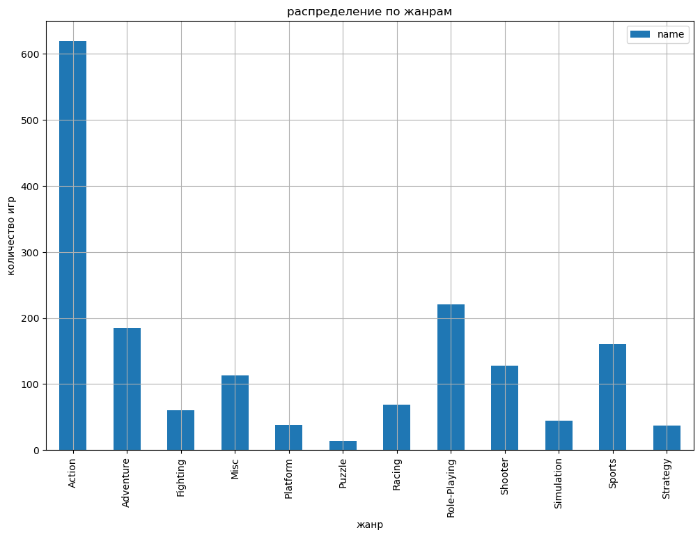

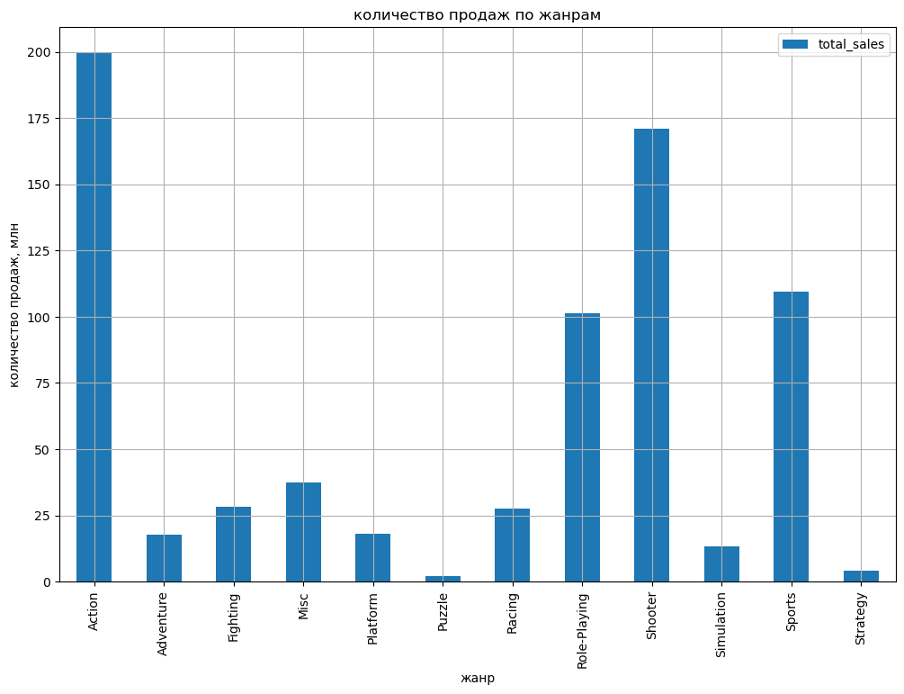

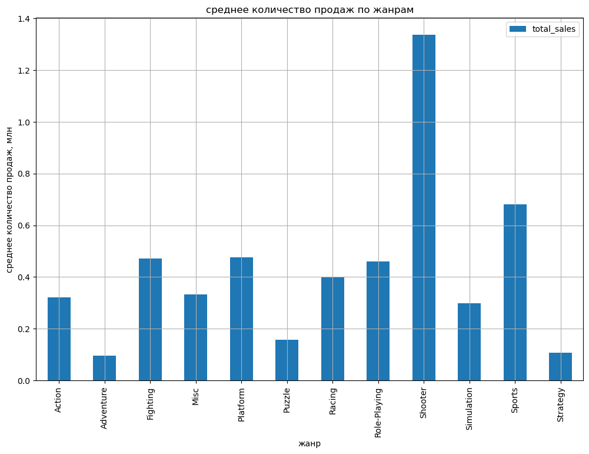

```python
genre = data2.pivot_table(index='genre', values='name', aggfunc='count')
genre.plot(title='распределение по жанрам', xlabel='жанр', ylabel='количество игр', grid=True, kind='bar', figsize=(12,8))
genre_sales = data2.pivot_table(index='genre', values='total_sales', aggfunc='sum')
genre_sales.plot(title='количество продаж по жанрам', xlabel='жанр', ylabel='количество продаж, млн', grid=True, kind='bar', figsize=(12,8))
genre_sales_mean = data2.pivot_table(index='genre', values='total_sales', aggfunc='mean')
genre_sales_mean.plot(title='среднее количество продаж по жанрам', xlabel='жанр', ylabel='среднее количество продаж, млн', grid=True, kind='bar', figsize=(12,8));
```

Самым распространенным и самым продаваемым жанром за последние 3 года Action. Однако, средние продажи за выпущенную игру у Shooter и Sports гораздо выше, чем у Action. Самыми малопродаваемыми жанрами являются Strategy, Puzzle, Simulation, Adenture, Platform. Также бы хотелось отметить, что игр с жанром Adenture выпускается довольно много, а вот продаж, как говорилось ранее, очень мало.

### Составим портрет пользователей для каждого региона

Определим самые популярные платформы для каждого региона:

| platform | na_sales |
| --- | --- |
| PS4 | 98.61 |
| XOne | 81.27 |
| X360 | 28.30 |
| 3DS | 22.64 |
| PS3 | 22.05 |

| platform | eu_sales |
| --- | --- |
| PS4 | 130.04 |
| XOne | 46.25 |
| PS3 | 25.54 |
| PC | 17.97 |
| 3DS | 16.12 |

| platform | jp_sales |
| --- | --- |
| 3DS | 44.24 |
| PS4 | 15.02 |
| PSV | 14.54 |
| PS3 | 11.22 |
| WiiU | 7.31 |

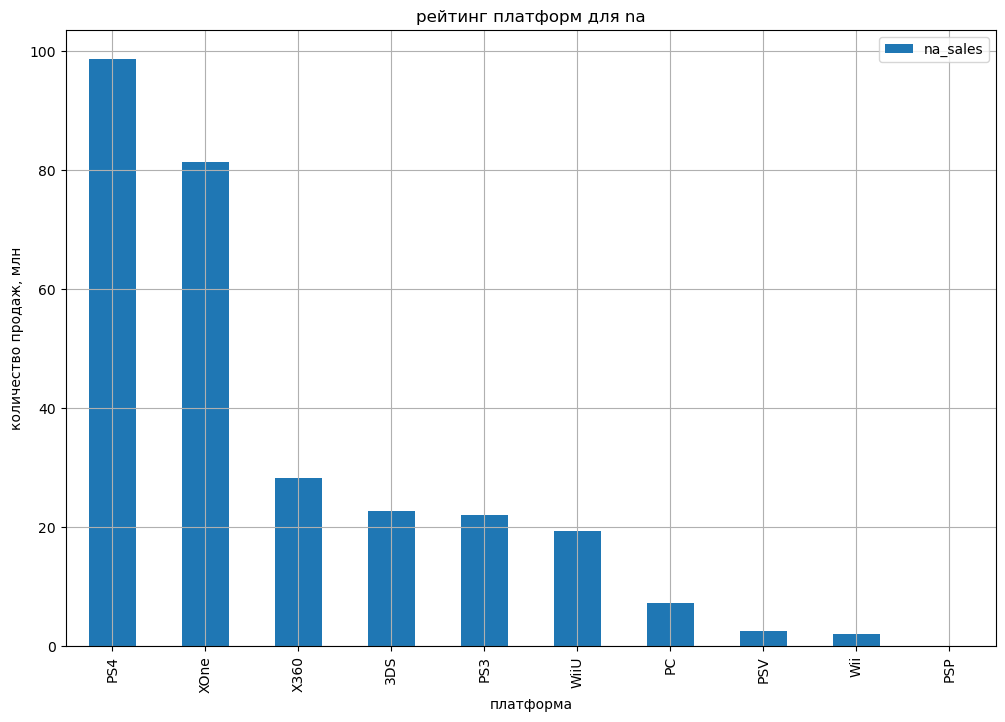

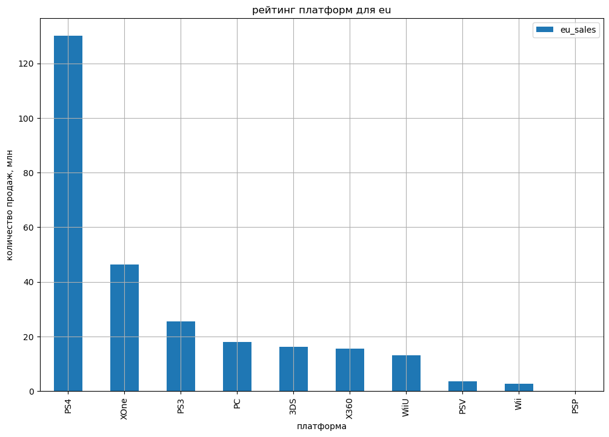

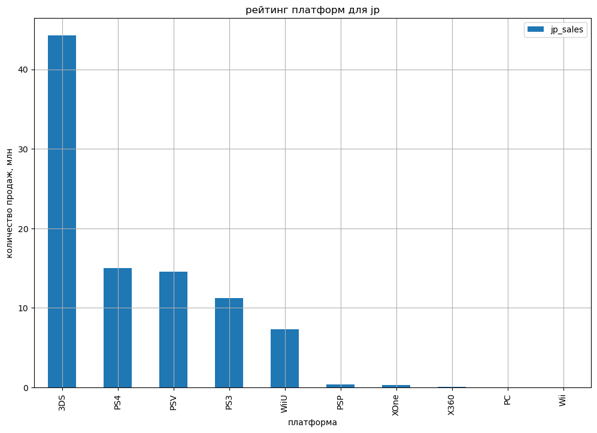

```python
platform_top_na = data2.pivot_table(index='platform', values='na_sales', aggfunc='sum').sort_values(by='na_sales', ascending=False)
platform_top_na.plot(title='рейтинг платформ для na', xlabel='платформа', \
                     ylabel='количество продаж, млн', grid=True, kind='bar', figsize=(12,8))
display(platform_top_na.head())
platform_top_eu = data2.pivot_table(index='platform', values='eu_sales', aggfunc='sum').sort_values(by='eu_sales', ascending=False)
platform_top_eu.plot(title='рейтинг платформ для eu', xlabel='платформа', \
                     ylabel='количество продаж, млн', grid=True, kind='bar', figsize=(12,8))
display(platform_top_eu.head())
platform_top_jp = data2.pivot_table(index='platform', values='jp_sales', aggfunc='sum').sort_values(by='jp_sales', ascending=False)
platform_top_jp.plot(title='рейтинг платформ для jp', xlabel='платформа', \
                     ylabel='количество продаж, млн', grid=True, kind='bar', figsize=(12,8))
display(platform_top_jp.head())
```

В регионах na и eu в целом предпочтения в платформах схожи. Но есть и отличия, главное из них - в eu довольно популярна платформа PC, в отличии от na. Также в na все ещё довольна платформа X360, в отличии от eu. А вот в регионе jp совсем другие предпочтения. На первом месте платформа 3DS, которая в других регионах расположилась на 4 и 5 местах в топ 5. Также в топ 5 попали PSV и WiiU, которых и вовсе нету в других регионах в топ 5. А такая популярная платформа, как ХOne - вообще практически не используется.

Определим самые популярные жанры для разных регионов

| genre | na_sales |
| --- | --- |
| Shooter | 79.02 |
| Action | 72.53 |
| Sports | 46.13 |
| Role-Playing | 33.47 |
| Misc | 15.05 |

| genre | eu_sales |
| --- | --- |
| Action | 74.68 |
| Shooter | 65.52 |
| Sports | 45.73 |
| Role-Playing | 28.17 |
| Racing | 14.13 |

| genre | jp_sales |
| --- | --- |
| Role-Playing | 31.16 |
| Action | 29.58 |
| Fighting | 6.37 |
| Misc | 5.61 |
| Shooter | 4.87 |

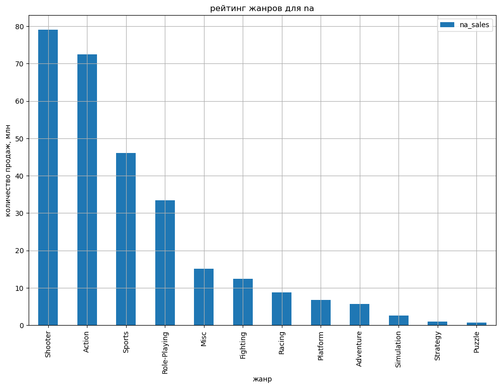

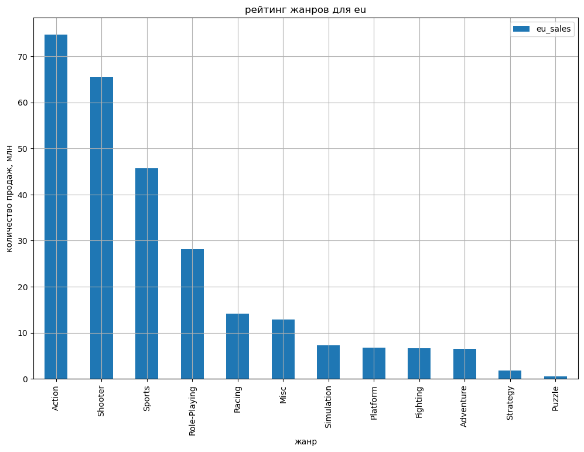

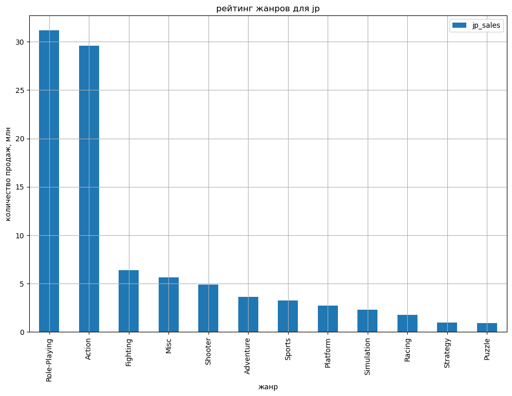

```python
genre_top_na = data2.pivot_table(index='genre', values='na_sales', aggfunc='sum').sort_values(by='na_sales', ascending=False)
genre_top_na.plot(title='рейтинг жанров для na', xlabel='жанр', \
                     ylabel='количество продаж, млн', grid=True, kind='bar', figsize=(12,8))
display(genre_top_na.head())
genre_top_eu = data2.pivot_table(index='genre', values='eu_sales', aggfunc='sum').sort_values(by='eu_sales', ascending=False)
genre_top_eu.plot(title='рейтинг жанров для eu', xlabel='жанр', \
                     ylabel='количество продаж, млн', grid=True, kind='bar', figsize=(12,8))
display(genre_top_eu.head())
genre_top_jp = data2.pivot_table(index='genre', values='jp_sales', aggfunc='sum').sort_values(by='jp_sales', ascending=False)
genre_top_jp.plot(title='рейтинг жанров для jp', xlabel='жанр', \
                     ylabel='количество продаж, млн', grid=True, kind='bar', figsize=(12,8))
display(genre_top_jp.head())
```

В жанрах наблюдается похожая картина. В регионе na и eu предпочтения по жанрам схожи. Из отличий можно отметить, что Action и Shooter поменялись местами, а также в регионе na отдают предпочтения жанру Misc, нежели Racing в eu. В регионе jp топ-5 отличается сильнее.Тут очень любят играть в Role-Playing и Action. Причем, эти два жанра очень сильно превалируют над другими.Также следует отметить, что в топ 5 попал жанр Fighting, который не очень популярен в других регионах.

Проверим, как влияет рейтинг ESRB на продажи в отдельных регионах:

| rating | na_sales |
| --- | --- |
| M | 96.42 |
| undefind | 64.72 |
| E | 50.74 |
| T | 38.95 |
| E10+ | 33.23 |

| rating | eu_sales |
| --- | --- |
| M | 93.44 |
| undefind | 58.95 |
| E | 58.06 |
| T | 34.07 |
| E10+ | 26.16 |

| rating | jp_sales |
| --- | --- |
| undefind | 56.90 |
| T | 14.78 |
| E | 8.94 |
| M | 8.01 |
| E10+ | 4.46 |

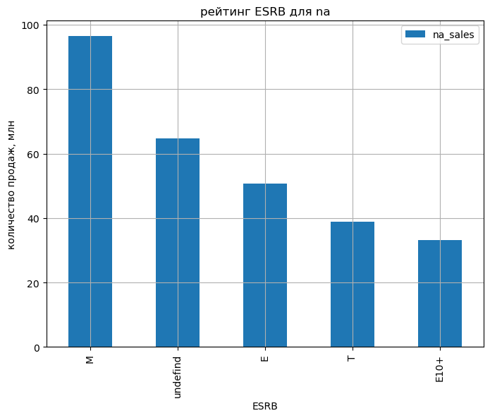

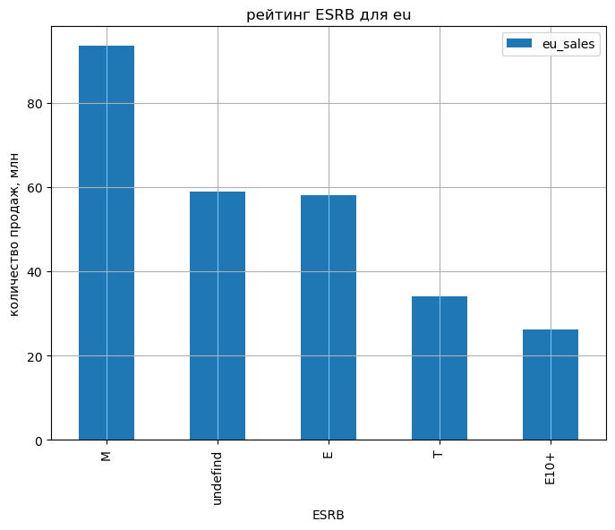

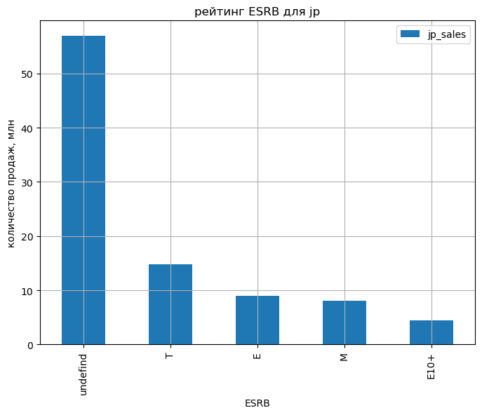

```python
esrb_top_na = data2.pivot_table(index='rating', values='na_sales', aggfunc='sum').sort_values(by='na_sales', ascending=False)
esrb_top_na.plot(title='рейтинг ESRB для na', xlabel='ESRB', \
                     ylabel='количество продаж, млн', grid=True, kind='bar', figsize=(8,6))
display(esrb_top_na.head())
esrb_top_eu = data2.pivot_table(index='rating', values='eu_sales', aggfunc='sum').sort_values(by='eu_sales', ascending=False)
esrb_top_eu.plot(title='рейтинг ESRB для eu', xlabel='ESRB', \
                     ylabel='количество продаж, млн', grid=True, kind='bar', figsize=(8,6))
display(esrb_top_eu.head())
esrb_top_jp = data2.pivot_table(index='rating', values='jp_sales', aggfunc='sum').sort_values(by='jp_sales', ascending=False)
esrb_top_jp.plot(title='рейтинг ESRB для jp', xlabel='ESRB', \
                     ylabel='количество продаж, млн', grid=True, kind='bar', figsize=(8,6))
display(esrb_top_jp.head())
```

Как видим из графиков, в регионах na и eu идентичное распределение продаж игр в соотетствии с рейтингом ESRB. На первом месте игры с рейтингом M. В регионе jp - с рейтингом Т. Игры с рейтингом Е10+ во всех регионах имеют минимальные продажи. Следовательно, можно сделать вывод, что рейтинг ESRB влияет на продажи в разных регионах, особенно в регионах na и eu. Также бы хотелось отметить, что в регионе jp наибольшее количество пропусков в рейтинге ESRB в процентном соотношении.

### Проверка гипотез

Так как выборки содержат в себе больше 30 значений (100+), а также потому, что чаще всего критерий Стьюдента применяется для проверки равенства средних значений в двух выборках для проверки гипотез был применен параметрический t-критерий Стьюдента. А в следствии того, что выборки имеют разный размер, предположил что дисперсии выборок не равны.

Нулевая гипотеза: средние пользовательские рейтинги платформ Xbox One и PC одинаковые. Альтернативная гипотеза: средние пользовательские рейтинги платформ Xbox One и PC отличаются.

```python
data3 = data2.dropna(subset=['user_score'])
results = st.ttest_ind(data3['user_score'].loc[data2['platform'] == 'XOne'], \
                       data3['user_score'].loc[data2['platform'] == 'PC'], equal_var = False)
alpha = 0.05
print(results.pvalue)
if results.pvalue < alpha:
    print('Отвергаем нулевую гипотезу')
else:
    print('Не получилось отвергнуть нулевую гипотезу')
```

```
0.11601398086668832
Не получилось отвергнуть нулевую гипотезу
```

Нулевая гипотеза: средние пользовательские рейтинги жанров Action и Sports одинаковые. Альтернативная гипотеза: средние пользовательские рейтинги жанров Action и Sports отличаются.

```python
results = st.ttest_ind(data3['user_score'].loc[data2['genre'] == 'Action'], \
                       data3['user_score'].loc[data2['genre'] == 'Sports'], equal_var = False)
alpha = 0.05
print(results.pvalue)
if results.pvalue < alpha:
    print('Отвергаем нулевую гипотезу')
else:
    print('Не получилось отвергнуть нулевую гипотезу')
```

```
1.1825550382644557e-14
Отвергаем нулевую гипотезу
```

Гипотезы сформулированы исходя из задания, Нулевые взяты как равенство параметров, альтернитвные, соответственно, как различие параметров. Уровень критичекой значимости взят 5%.